# Laboratorio 2 IN5602 - Semestre Primavera 2021

Francisca Moraga

08 de Septiembre de 2021

# Machine Learning

Machine Learning es un conjunto de métodos que Automatizar la construcción de modelos analíticos y se basa en la idea de que los sistemas pueden aprender de los datos, identificar patrones y tomar decisiones con una mínima intervención humana.

Los problemas más típicos que resuelven los modelos de Machine Learning son 2:

1. Regresiones: Predicción de una variable continua
2. Clasificación: Predeción de una variable discreta

## División de los datos

Para dividir los datos podemos usar muestreo aleatorio (Por lo general, se divide haciendo “80-20”o “70-30”)

- Data train: Estos datos se utilizan para desarrollar conjuntos de características, entrenar el algoritmo, comparar modelos.
- Data test: Estos datos se utilizan para estimar una evaluación imparcial del rendimiento del modelo.

# Desarollo del laboratorio

## Enunciado

Se tiene información sobre ventas de propiedades en EE.UU y se requiere utilizar los atributos de estas propiedades para predecir el precio de venta de la vivienda.

- Tipo de problema: regresión supervisada ($Y$ es númerico)
- Resultado de interés: `Sale_Price` (en dólares)
- Características o variables explicativas $X$: 80
- Observaciones: 2.930
- Descripción Dataset: https://github.com/hunkim/KaggleZeroToAll/blob/master/k0-03-house-prices-advanced-regression-techniques/data_description.txt

```r
rm(list=ls())                #Limpia todos los objetos creados en R
graphics.off()           #Limpia los gráficos
options(digits = 3)  #Dígitos después del punto para observar (décimas, centésimas,...)
set.seed(12345)      #Fijar semilla de aleatoriedad
```

### Paquetes

```r
library(readr)     #Para leer CSV
library(glmnet)    #Para ajustar modelo lineal
library(corrplot)  #Para realizar correlogramas
library(dplyr)     #Para manipulación de datos
library(ggplot2)   #Para gráficos
library(caret)     #Para validar y entrenar los modelos
library(knitr)
```

### Carga de datos

```r
Casas <- read.csv("Casas.csv")
kable(Casas[1:5,1:9]) #kable crea una tabla head(Casas) sirve para visualiar la data
```

| X | MS_SubClass | MS_Zoning | Lot_Frontage | Lot_Area | Street | Alley | Lot_Shape | Land_Contour |
| --- | --- | --- | --- | --- | --- | --- | --- | --- |
| 1 | One_Story_1946_and_Newer_All_Styles | Residential_Low_Density | 141 | 31770 | Pave | No_Alley_Access | Slightly_Irregular | Lvl |
| 2 | One_Story_1946_and_Newer_All_Styles | Residential_High_Density | 80 | 11622 | Pave | No_Alley_Access | Regular | Lvl |
| 3 | One_Story_1946_and_Newer_All_Styles | Residential_Low_Density | 81 | 14267 | Pave | No_Alley_Access | Slightly_Irregular | Lvl |
| 4 | One_Story_1946_and_Newer_All_Styles | Residential_Low_Density | 93 | 11160 | Pave | No_Alley_Access | Regular | Lvl |
| 5 | Two_Story_1946_and_Newer | Residential_Low_Density | 74 | 13830 | Pave | No_Alley_Access | Slightly_Irregular | Lvl |

```r
#table(Casas$MS_SubClass)
Casas$MS_SubClass=as.factor(Casas$MS_SubClass)
Casas$MS_Zoning=as.factor(Casas$MS_Zoning)
Casas$Alley=as.factor(Casas$Alley)
Casas$Lot_Shape=as.factor(Casas$Lot_Shape)
Casas$Land_Contour=as.factor(Casas$Land_Contour)
Casas$Utilities=as.factor(Casas$Utilities)
Casas$Lot_Config=as.factor(Casas$Lot_Config)
Casas$Land_Slope=as.factor(Casas$Land_Slope)
Casas$Condition_1=as.factor(Casas$Condition_1)
Casas$Condition_2=as.factor(Casas$Condition_2)
Casas$Bldg_Type=as.factor(Casas$Bldg_Type)
Casas$House_Style=as.factor(Casas$House_Style)
Casas$Overall_Qual=as.factor(Casas$Overall_Qual)
Casas$Overall_Cond=as.factor(Casas$Overall_Cond)
Casas$Roof_Style=as.factor(Casas$Roof_Style)
Casas$Roof_Matl=as.factor(Casas$Roof_Matl)
Casas$Exterior_1st=as.factor(Casas$Exterior_1st)
Casas$Exterior_2nd=as.factor(Casas$Exterior_2nd)
Casas$Mas_Vnr_Type=as.factor(Casas$Mas_Vnr_Type)
Casas$Exter_Qual=as.factor(Casas$Exter_Qual)
Casas$Heating=as.factor(Casas$Heating)
Casas$Heating_QC=as.factor(Casas$Heating_QC)
```

### División de los datos

Vamos a escoger 70% entrenamiento y 30% para testeo:

```r
# Construimos un vector que esta formado por números de filas aleatoriamente
index <- sample(1:nrow(Casas), size= nrow(Casas)*0.7)
# Base de entrenamiento: del total de datos, tomamos las filas aletorizadas que tienen datos en index
train <- Casas[index, ]
# Anteponiendo el "-" escogemos las filas en de la base que no están en index
test  <- Casas[-index, ]
```

### EDA

Antes de entrenar un modelo predictivo, o incluso antes de realizar cualquier cálculo con un nuevo conjunto de datos, es muy importante realizar una exploración descriptiva de los mismos. Este proceso permite entender mejor que información contiene cada variable, así como detectar posibles errores.

#### Variable de interés

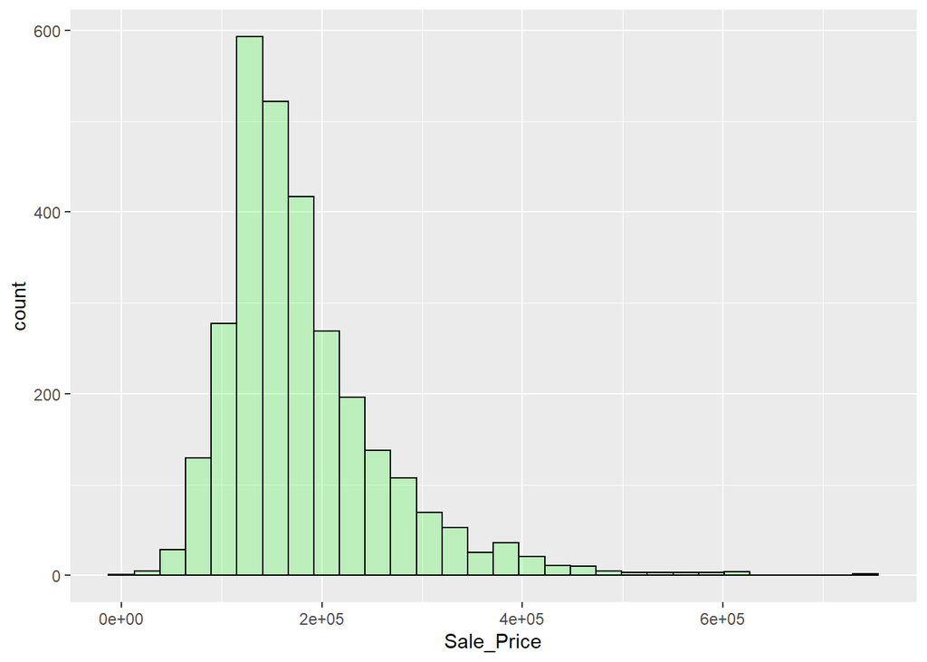

```r
ggplot(data=Casas)+ #Se define un gráfico con ggplot()
  aes(x=Sale_Price)+ #Solo le ingresamos el eje "x" para un histograma
  geom_histogram(col="black", fill="green", alpha = 0.2) # Se define la forma del gráfico. "col" pinta el contorno, "fill" el entorno y "alpha" entrega transparencia
```

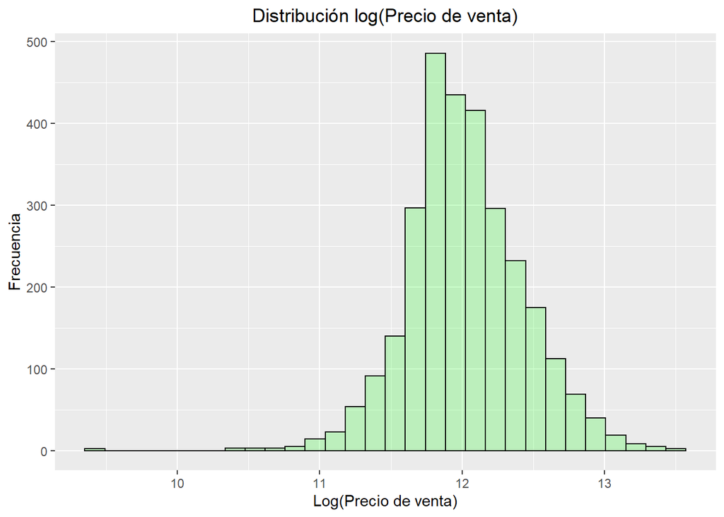

```r
ggplot(data=Casas)+
  aes(x=log(Sale_Price))+
  geom_histogram(col="black", fill="green", alpha=0.2)+
  xlab("Log(Precio de venta)")+ #Etiqueta para el eje x
  ylab("Frecuencia")+ #Etiqueta para el eje y
  ggtitle("Distribución log(Precio de venta)")+ #Título del gráfico
  theme(plot.title = element_text(hjust = 0.5)) #centra el título en el gráfico. Lo ajusta en la posición horizontal (hjust = 0.5)
```

#### Variables explicativas

Escogemos algunas variables: `Year_Built` (Año en que se construyó la casa), `Roof_Style` (Tipo de techo), `Gr_Liv_Area` (espacio habitable total sobre el suelo de una casa) y `Heating_QC`(Calidad y estado de la calefacción)

##### `Year_Built`

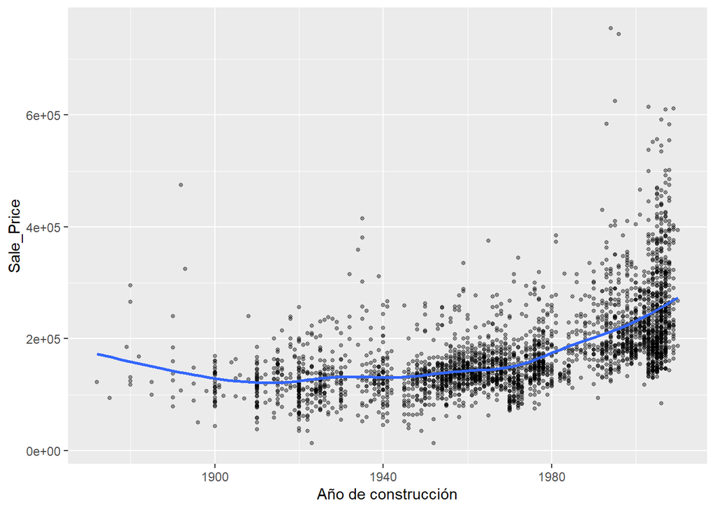

```r
library(gridExtra) #Para unir gráficas
ggplot(Casas) +
  aes(x=Year_Built, y=Sale_Price) +
  geom_point(size=1, alpha=0.4) + #"size" aumenta el tamaño de los puntos, "alpha" da transparencia
  geom_smooth(se=FALSE) + #Agregamos un ajuste no lineal sobre los puntos. "se" integra errores estándares
  xlab("Año de construcción")
```

##### `Gr_Liv_Area` según `Heating_QC`

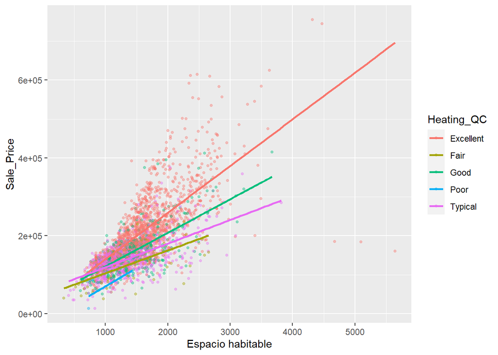

```r
ggplot(Casas) +
  aes(x=Gr_Liv_Area, y=Sale_Price, col=Heating_QC)+ #Se agrega una dimensión de colores "col".
  geom_point(size=1, alpha=0.4) +
  geom_smooth(se=FALSE, method="lm") +
  xlab("Espacio habitable")
```

##### `Roof_Style`

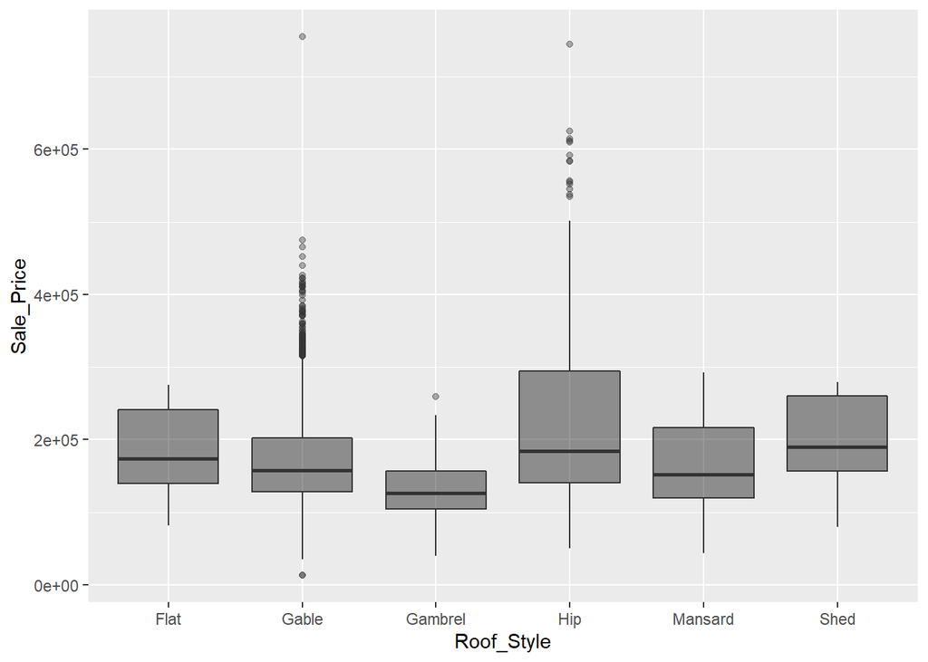

```r
ggplot(Casas) +
  aes(x=Roof_Style, y=Sale_Price) +
  geom_boxplot(alpha=0.4, fill="black") #cambiamos el tipo de gráfico
```

## Regresión Lineal

```r
train.lm <- train(form = Sale_Price ~ Year_Built+Gr_Liv_Area+Roof_Style+Heating_QC, #Fórmula
  data = train, #Datos
  method = "lm", #Algoritmo
  trControl = trainControl(method = "cv", number = 10) #Method = cross validation, number=10 (k-fold)
)

test.lm  <- predict(train.lm , newdata=test) #Vector de datos predichos. Recibe una base de datos (newdata) y un modelo entrenado (train.lm)
error.lm <- test$Sale_Price-test.lm #Calcular los errores de predicción (dato real - dato estimado)
```

## MARS

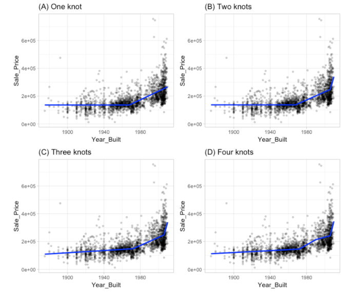

```r
#Ejecutar MARS (Multivariate adaptive regression spline)
train.mars <- train(form = Sale_Price ~ Year_Built+Gr_Liv_Area+Roof_Style+Heating_QC,
                    data=train,
                    method="earth", #MARS
                    trControl = trainControl("cv", number=10),
                    preProcess = c("center","scale"), #Pre-procesa datos. "center" resta el promedio de las variables, "scale" las divide por la desviación estandar. Esto ayuda para el tratamiento de outliers.
                    tuneLength = 5 #Indica que pruebe diferentes valores por default para el parámetro principal
)
print(train.mars)
```

```
## Multivariate Adaptive Regression Spline
##
## 2051 samples
##    4 predictor
##
## Pre-processing: centered (11), scaled (11)
## Resampling: Cross-Validated (10 fold)
## Summary of sample sizes: 1847, 1846, 1845, 1844, 1845, 1846, ...
## Resampling results across tuning parameters:
##
##   nprune  RMSE   Rsquared  MAE
##   2       56407  0.510     38929
##   3       47313  0.655     32514
##   5       46666  0.671     30947
##   6       44557  0.700     29511
##   8       44748  0.702     29549
##
## Tuning parameter 'degree' was held constant at a value of 1
## RMSE was used to select the optimal model using the smallest value.
## The final values used for the model were nprune = 6 and degree = 1.
```

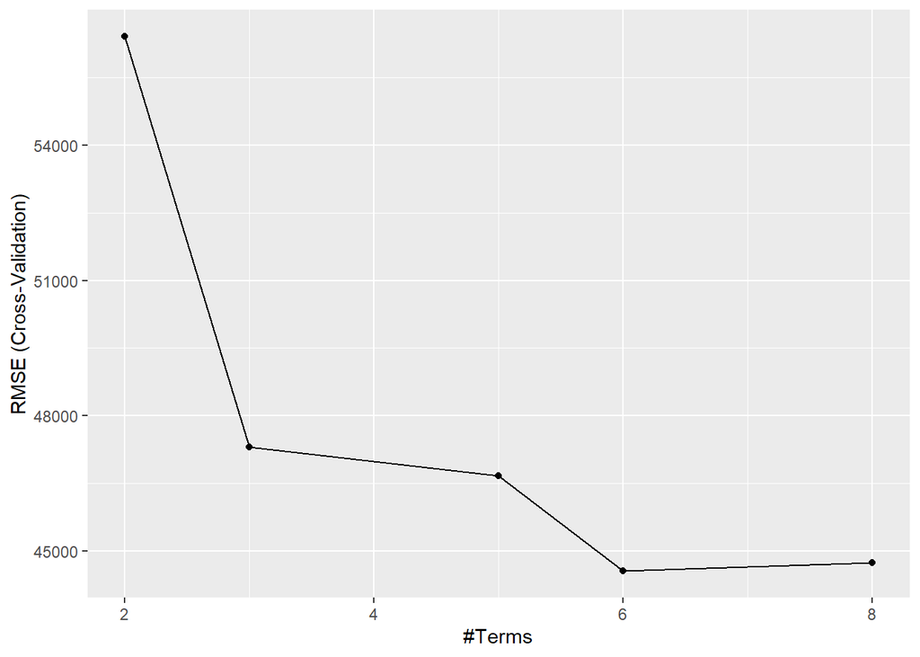

```r
ggplot(train.mars)
```

```r
test.mars  <- predict(train.mars, newdata=test) #Vector de datos predichos
error.mars <- test$Sale_Price-test.mars #(dato real - dato estimado)
```

## K-Nearest Neighbors

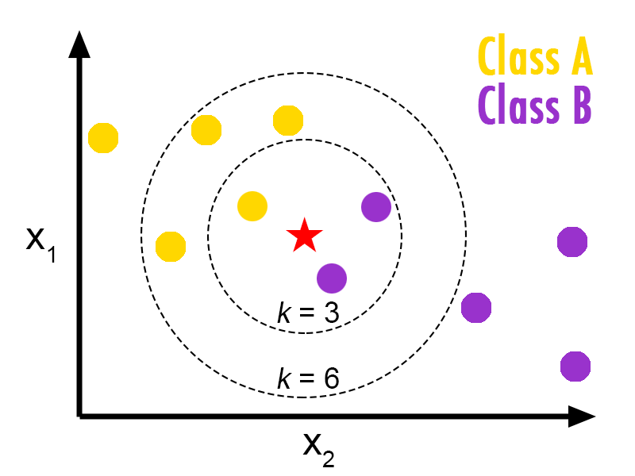

```r
### Ejecutar KNN
train.knn <- train(Sale_Price ~ Year_Built+Gr_Liv_Area+Roof_Style+Heating_QC,
                   data=train, method="knn",
                   trControl = trainControl("cv", number=10),
                   preProcess = c("center","scale"),
                   tuneLength = 5
)

print(train.knn)
```

```
## k-Nearest Neighbors
##
## 2051 samples
##    4 predictor
##
## Pre-processing: centered (11), scaled (11)
## Resampling: Cross-Validated (10 fold)
## Summary of sample sizes: 1846, 1847, 1846, 1845, 1846, 1845, ...
## Resampling results across tuning parameters:
##
##   k   RMSE   Rsquared  MAE
##    5  41168  0.740     27443
##    7  40575  0.746     27071
##    9  40271  0.749     26946
##   11  40230  0.749     26801
##   13  40483  0.746     26826
##
## RMSE was used to select the optimal model using the smallest value.
## The final value used for the model was k = 11.
```

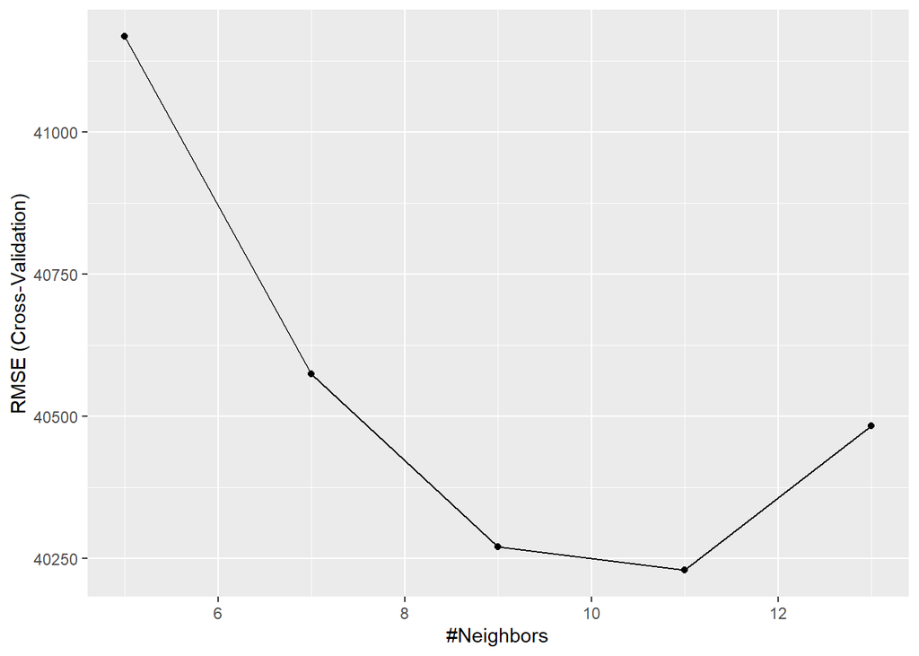

```r
ggplot(train.knn)
```

```r
test.knn  <- predict(train.knn, newdata=test)
error.knn <- test$Sale_Price-test.knn
```

## CART

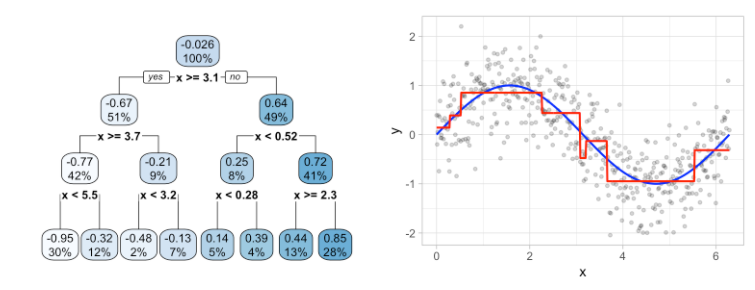

```r
### Ejecutar CART (Classification and Regression Trees)
train.cart <- train(Sale_Price ~ Year_Built+Gr_Liv_Area+Roof_Style+Heating_QC,
                    data=train, method="rpart2",
                    trControl = trainControl("cv", number=10),
                    preProcess = c("center","scale"),
                    tuneLength = 5
)
print(train.cart)
```

```
## CART
##
## 2051 samples
##    4 predictor
##
## Pre-processing: centered (11), scaled (11)
## Resampling: Cross-Validated (10 fold)
## Summary of sample sizes: 1846, 1848, 1845, 1847, 1845, 1846, ...
## Resampling results across tuning parameters:
##
##   maxdepth  RMSE   Rsquared  MAE
##   1         64227  0.366     44315
##   2         55454  0.526     38751
##   3         53319  0.562     37587
##   4         52069  0.583     36415
##   5         45363  0.681     31887
##
## RMSE was used to select the optimal model using the smallest value.
## The final value used for the model was maxdepth = 5.
```

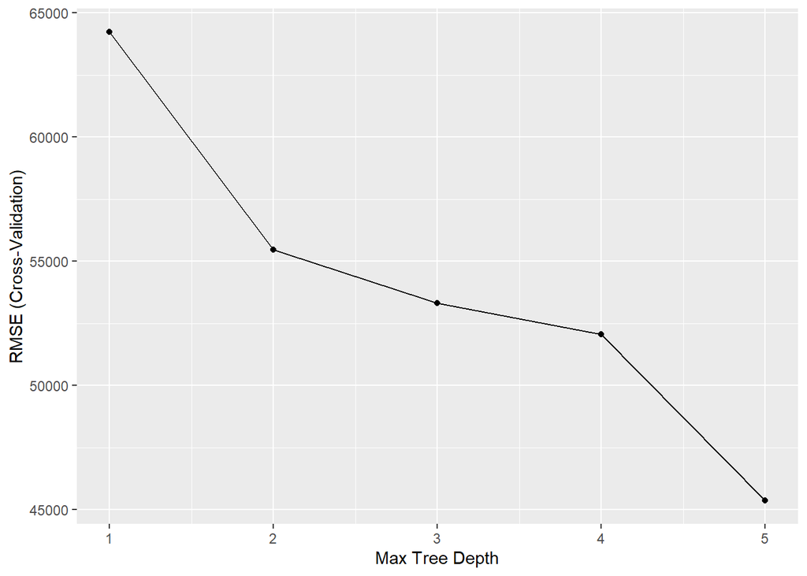

```r
ggplot(train.cart)
```

```r
test.cart  <- predict(train.cart, newdata=test)
error.cart <- test$Sale_Price-test.cart
```

## Random Forest

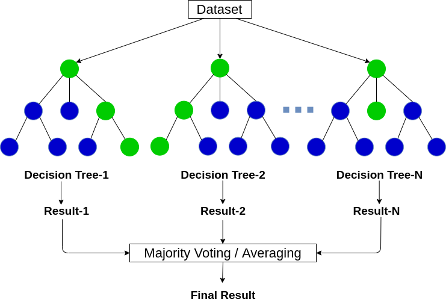

```r
### Ejecutar Random Forest
train.randomf <- train(Sale_Price ~ Year_Built+Gr_Liv_Area+Roof_Style+Heating_QC,
                       data=train, method="rf",
                       trControl = trainControl("cv", number=10),
                       preProcess = c("center","scale"),
                       tuneLength = 5
)
print(train.randomf)
```

```
## Random Forest
##
## 2051 samples
##    4 predictor
##
## Pre-processing: centered (11), scaled (11)
## Resampling: Cross-Validated (10 fold)
## Summary of sample sizes: 1845, 1846, 1847, 1845, 1846, 1846, ...
## Resampling results across tuning parameters:
##
##   mtry  RMSE   Rsquared  MAE
##    2    47824  0.711     32036
##    4    40078  0.761     26617
##    6    38666  0.772     25460
##    8    38962  0.769     25629
##   11    39593  0.763     26043
##
## RMSE was used to select the optimal model using the smallest value.
## The final value used for the model was mtry = 6.
```

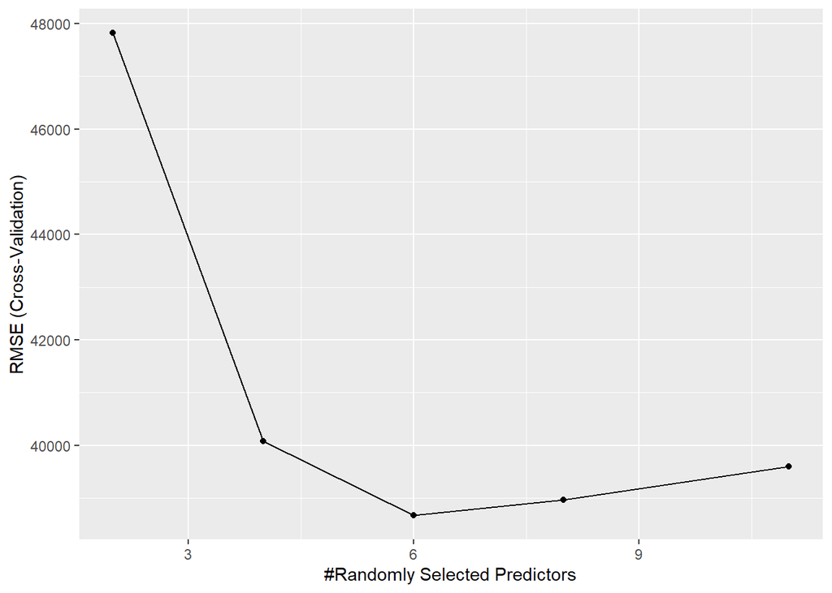

```r
ggplot(train.randomf)
```

```r
test.randomf  <- predict(train.randomf, newdata=test)
error.randomf <- test$Sale_Price-test.randomf
```

## Comparación de modelos

```r
sales.test <- data.frame(lm=test.lm, mars=unname(test.mars),  knn=test.knn,  cart=test.cart,  rf=test.randomf, sales=test$Sale_Price)
error.test <- data.frame(lm=error.lm, mars=unname(error.mars), knn=error.knn, cart=error.cart, rf=error.randomf)

summary(abs(error.test))
```

```
##        lm              mars             knn              cart
##  Min.   :    31   Min.   :   109   Min.   :     9   Min.   :    13
##  1st Qu.:  9891   1st Qu.:  9433   1st Qu.:  8000   1st Qu.: 10387
##  Median : 22802   Median : 20667   Median : 19077   Median : 23566
##  Mean   : 30386   Mean   : 28870   Mean   : 27700   Mean   : 32816
##  3rd Qu.: 40731   3rd Qu.: 38102   3rd Qu.: 36841   3rd Qu.: 43279
##  Max.   :475711   Max.   :439686   Max.   :306721   Max.   :276079
##        rf
##  Min.   :   191
##  1st Qu.:  7625
##  Median : 17177
##  Mean   : 25016
##  3rd Qu.: 33002
##  Max.   :279007
```

```r
summary(error.test)
```

```
##        lm               mars              knn               cart
##  Min.   :-475711   Min.   :-439686   Min.   :-306721   Min.   :-235019
##  1st Qu.: -26428   1st Qu.: -22404   1st Qu.: -23082   1st Qu.: -30352
##  Median :  -3344   Median :  -2192   Median :  -3282   Median :  -4574
##  Mean   :  -3070   Mean   :  -2374   Mean   :  -2287   Mean   :  -3593
##  3rd Qu.:  18394   3rd Qu.:  17228   3rd Qu.:  14475   3rd Qu.:  18398
##  Max.   : 212784   Max.   : 213843   Max.   : 258964   Max.   : 276079
##        rf
##  Min.   :-279007
##  1st Qu.: -21182
##  Median :  -3466
##  Mean   :  -2657
##  3rd Qu.:  11921
##  Max.   : 193396
```

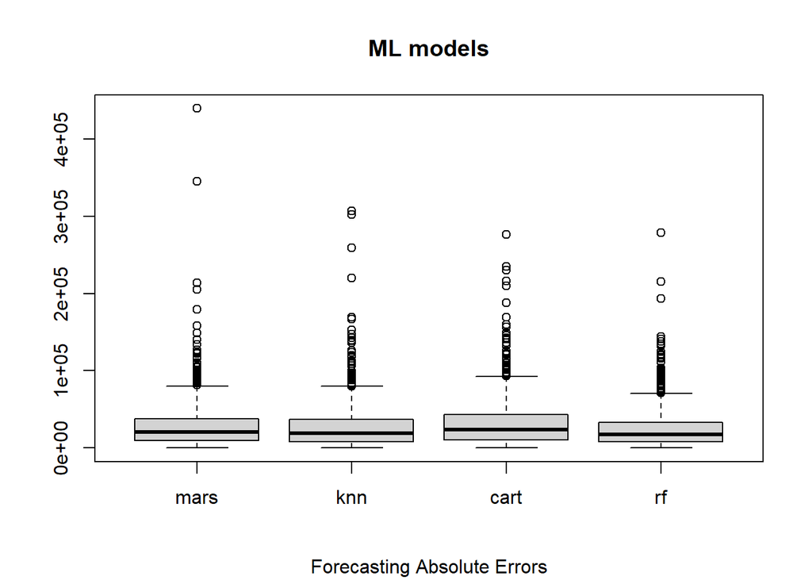

```r
boxplot(abs(subset(error.test, select=-lm))); title(main="ML models", sub="Forecasting Absolute Errors")
```

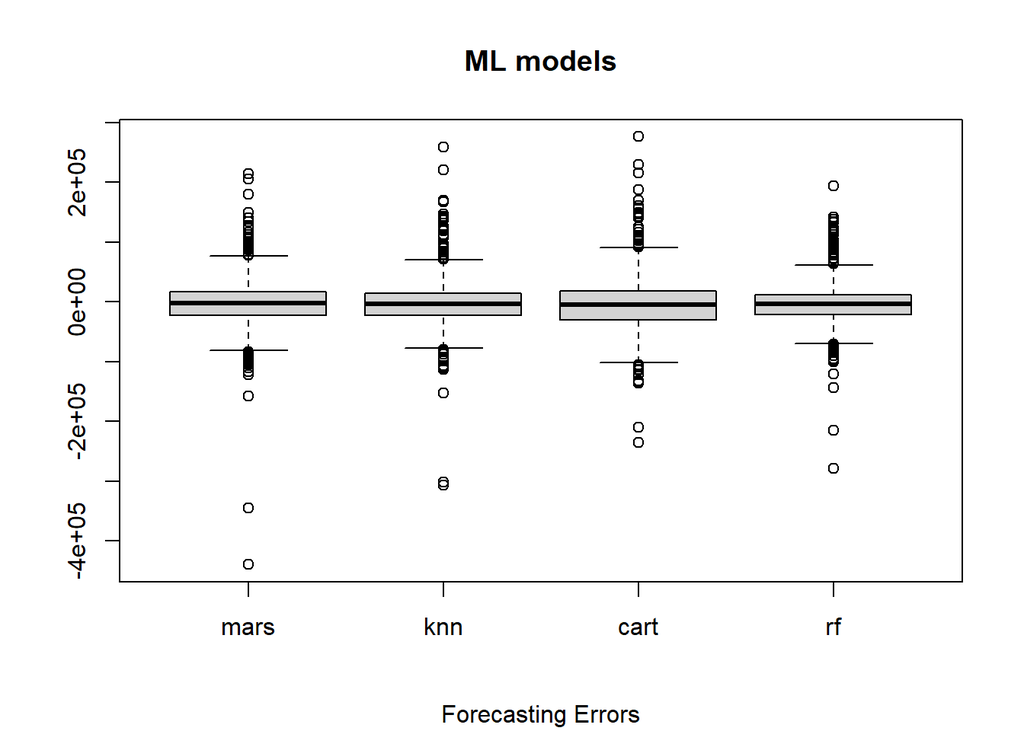

```r
boxplot(subset(error.test, select=-lm)); title(main="ML models", sub="Forecasting Errors")
```

## Preguntas

### Pregunta 1

```r
#Escoja 10 variables continuas u categóricas (no con tantas categorías)
#De esas 10, debe argumentar para al menos 3 de ellas porque podrían ser predictoras del precio de la casa.
#Construya una base de datos reducida con "Casas <- Casas[,c(x1,x2,x3,...x10)]"
# x1,...,x10 son las posiciones de las variables en la base de datos Casas
```

### Pregunta 2

```r
#Corra 1 modelo de regresión lineal y 2 modelos de Machine Learning vistos en la clase con la base de datos reducida,  para predecir el precio de las casas.
```

### Pregunta 3

```r
# Comparación de Modelos: Compare los modelos a través de métricas presentadas en el laboratorio.
# ¿Cuál es el mejor modelo predictivo?
```